# STAT 420 - Project Proposal

Jonathan Bowen

2025-10-26

### Intro

The goal of my analysis is to explore how various environmental and weather factors can help predict observations of the Common Raven.  
I plan to use a composite dataset for my project. The primary source of my data is the Cornell Lab of Ornithology’s [eBird Basic Dataset](https://ebird.org/data/download/ebd), sometimes called “EBD”. As described on their website, “[eBird](https://ebird.org/home) is among the world’s largest biodiversity-related science projects” and “eBird data document bird distribution, abundance, habitat use, and trends through checklist data collected within a simple, scientific framework.” eBird makes available the full dataset of observations upon request. It is a ~220 GB archive that expands to a ~785 GB text file when extracted.

Each entry/row of the eBird dataset includes fields/columns for species of bird observed, number of individuals observed, date, time, location, and many more.  
I am then using the [`elevatr` R package from the US EPA](https://github.com/USEPA/elevatr) to translate the eBird-observation latitude and longitude values into elevation above sea level, to serve as a more interesting numerical predictor.  
I am also using the [Visual Crossing API](https://www.visualcrossing.com/resources/documentation/weather-api/timeline-weather-api/) to gather weather data for each bird-observation location (lat/long) and date. Specifically, I will use the day’s average temperature, total precipitation, average wind speed, and overall “conditions” (serving as a categorical predictor) in the regression. Visual Crossing allows access to the API for registered users, and a free account allows 1000 queries per day.  
Finally, I use the [NASA Ocean Biology Processing Group’s “Distance to the Nearest Coast” dataset](https://oceancolor.gsfc.nasa.gov/resources/docs/distfromcoast/) to associate each bird-observation location (lat/long) with distance from the nearest coast. This dataset is a text file NASA makes available for download.

[figure not shown]

I am doing this as a solo project.  
I started with the Common Raven because it is fairly widespread but not completely ubiquitous in the US. I may decide to change what species I’m targeting as I proceed with the project. The below map shows the Common Raven’s range in North America (source: https://www.audubon.org/field-guide/bird/common-raven):

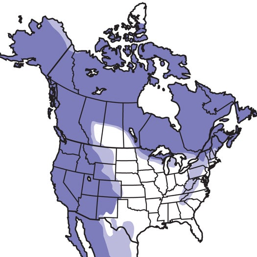

In summary, these will be the predictors:  
- hour of day (extracted from observation timestamp) (numeric) - elevation (numeric) - distance from coast (numeric) - day’s avg temp (numeric) - day’s precipitation amount (numeric) - day’s avg wind speed (numeric) - day’s general weather “conditions” (categorical)  
And the response variable will be number of Common Ravens observed.

### Citation for eBird data use

*eBird Basic Dataset. Version: EBD_relSep-2025. Cornell Lab of Ornithology, Ithaca, New York. Sep 2025.* (https://science.ebird.org/en/use-ebird-data/citation)

### Setup/packages

I am using the auk R package to interface with the EBD dataset.

```r
library(auk)
library(tidyverse)
library(magrittr)
library(httr)
library(data.table)
library(plotly)
library(elevatr)
```

```r
PROJECT_DIR = getwd()
ebd_full_dir = file.path(PROJECT_DIR, "source_data", "ebd_relSep-2025")
ebd_full_filename = "ebd_relSep-2025.txt"
```

### eBird Data Extraction using [`auk`](https://github.com/CornellLabofOrnithology/auk)

```r
f_out_full <- file.path(PROJECT_DIR, "output", "ebd_data_raven_SC_2024.txt")
f_in_full <- file.path(ebd_full_dir, ebd_full_filename)
ebd_filters <- auk_ebd(f_in_full) %>%
    auk_country("United States") %>%
    auk_state("US-SC") %>%
    auk_species("Common Raven") %>%
    auk_date(c("2024-01-01", "2025-01-01")) %>%
    auk_time(c("06:00", "19:00"))
```

I am not evaluating the below code in the RMarkdown because filtering the 785 GB dataset takes 2 hrs, but this is the code I used to extract my 2024 SC Common Raven observations originally:

```r
ebd_df <- auk_filter(ebd_filters, file = f_out_full) %>%
    read_ebd(unique=TRUE, rollup=TRUE)
```

Since I previously used the code shown above to store my filtered data into f_out_full, I can more quickly load the data frame into RMarkdown from there:

```r
f_in_full_already_processed = f_out_full
ebd_df = read_ebd(f_in_full_already_processed, unique=TRUE, rollup=TRUE)
str(ebd_df)
```

```
## tibble [293 × 51] (S3: tbl_df/tbl/data.frame)
##  $ checklist_id             : chr [1:293] "G11440833" "G11794337" "G11800868" "G11816471" ...
##  $ global_unique_identifier : chr [1:293] "URN:CornellLabOfOrnithology:EBIRD:OBS1911781251" "URN:CornellLabOfOrnithology:EBIRD:OBS1963129228" "URN:CornellLabOfOrnithology:EBIRD:OBS1963935305" "URN:CornellLabOfOrnithology:EBIRD:OBS1966501183" ...
##  $ last_edited_date         : chr [1:293] "2024-01-02 08:45:19.612788" "2024-02-26 04:33:29.084061" "2025-08-23 21:42:50.111994" "2024-03-01 03:31:36.090061" ...
##  $ taxonomic_order          : int [1:293] 21400 21400 21400 21400 21400 21400 21400 21400 21400 21400 ...
##  $ category                 : chr [1:293] "species" "species" "species" "species" ...
##  $ taxon_concept_id         : chr [1:293] "avibase-B9B272F4" "avibase-B9B272F4" "avibase-B9B272F4" "avibase-B9B272F4" ...
##  $ common_name              : chr [1:293] "Common Raven" "Common Raven" "Common Raven" "Common Raven" ...
##  $ scientific_name          : chr [1:293] "Corvus corax" "Corvus corax" "Corvus corax" "Corvus corax" ...
##  $ exotic_code              : chr [1:293] NA NA NA NA ...
##  $ observation_count        : chr [1:293] "1" "1" "1" "2" ...
##  $ breeding_code            : chr [1:293] NA NA NA NA ...
##  $ breeding_category        : chr [1:293] NA NA NA NA ...
##  $ behavior_code            : chr [1:293] NA NA NA NA ...
##  $ age_sex                  : chr [1:293] NA NA NA NA ...
```

[output cut: 38 more lines]

Here are the observation locations plotted on a map of the state:

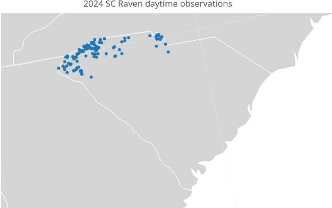

### Add elevation (elevatr)

```r
add_elev_data = function(ebd_df) {
    ebd_df$elevation = get_elev_point(locations = data.frame(x = ebd_df$longitude, y = ebd_df$latitude), units="feet",  prj = "EPSG:4326", src = "epqs")$elevation
    ebd_df
}
```

```r
ebd_df_with_elev = add_elev_data(ebd_df)
```

### Add weather (Visual Crossing)

```r
VisualCrossing_key = Sys.getenv("VISUAL_CROSSING_API_KEY")

get_weather_df = function(lat, long, date) {
       base_url_with_date_and_loc = sprintf("weather.visualcrossing.com/VisualCrossingWebServices/rest/services/timeline/%.3f%%2C%%20%.3f/%s", lat, long, date)
       full_weather_req_url <- list(hostname = base_url_with_date_and_loc,
                                    scheme = "https",
                                    query = list(unitGroup = "us",
                                                 include = "days",
                                                 key = VisualCrossing_key,
                                                 contentType = "csv")) %>%
              setattr("class","url") %>%
              build_url()
       # adapted URL construction from here: https://stackoverflow.com/questions/53350738/build-an-url-with-parameters-in-r
       (weather_df = read.csv(full_weather_req_url))
}
# Adapted query from example code here: https://www.visualcrossing.com/weather-query-builder/

add_weather_data = function(ebd_df) {
    weather_cols = c("temp", "precip", "windspeed", "cloudcover", "conditions")
    # Create empty columns to hold new data
    weather_cols_numeric = c("temp", "precip", "windspeed", "cloudcover")
    weather_cols_str = c("conditions")
    for (col in weather_cols_numeric) {
        ebd_df[col] = rep(0.0, nrow(ebd_df))
    }
    for (col in weather_cols_str) {
        ebd_df[col] = rep("", nrow(ebd_df))
    }

    for (x in 1:nrow(ebd_df)) {
        weather_df = get_weather_df(ebd_df[x, "latitude"], ebd_df[x, "longitude"], ebd_df[x, "observation_date"])
        for (col in weather_cols) {
            # print(weather_df[col])
            ebd_df[x, col] = weather_df[col]
        }
        Sys.sleep(0.1)
    }
    ebd_df
}
```

```r
ebd_df_with_elev_and_weather = add_weather_data(ebd_df_with_elev)
```

### Add dist-to-coast (NASA)

```r
dist_to_coast_filepath = file.path(PROJECT_DIR, "source_data", "NASA_dist2coast.txt")
dist_to_coast_df = read.delim(dist_to_coast_filepath, header = FALSE, col.names = c("long", "lat", "dist_km"))
```

```r
match_threshold = 0.05 # km

get_dist_from_coast = function(target_lat, target_long) {
    close_enough_lat_filter = (abs(dist_to_coast_df["lat"] - target_lat) < match_threshold)
    close_enough_lat = dist_to_coast_df[close_enough_lat_filter,]
    close_enough_long_filter = (abs(close_enough_lat["long"] - target_long) < match_threshold)
    loc_matches = close_enough_lat[close_enough_long_filter,]
    # If >1 match, take average distance
    mean(loc_matches[["dist_km"]])
}

add_dist_to_coast = function(ebd_df) {
    ebd_df["dist_to_coast_mi"] = rep(0.0, nrow(ebd_df))
    for (x in 1:nrow(ebd_df)) {
        ebd_df[x, "dist_to_coast_mi"] = -round(0.62137 * get_dist_from_coast(ebd_df[[x, "latitude"]], ebd_df[[x, "longitude"]]), 3)
    }
    ebd_df
}
```

```r
ebd_df_with_elev_and_weather_and_dist_to_coast = add_dist_to_coast(ebd_df_with_elev_and_weather)
head(ebd_df_with_elev_and_weather_and_dist_to_coast[c("global_unique_identifier",
                                                      "observation_count",
                                                      "latitude",
                                                      "longitude",
                                                      "observation_date",
                                                      "elevation",
                                                      "dist_to_coast_mi")])
```

```
## # A tibble: 6 × 7
##   global_unique_identifier observation_count latitude longitude observation_date
##   <chr>                    <chr>                <dbl>     <dbl> <date>
## 1 URN:CornellLabOfOrnitho… 1                     34.9     -81.9 2024-01-01
## 2 URN:CornellLabOfOrnitho… 1                     34.7     -82.8 2024-02-25
## 3 URN:CornellLabOfOrnitho… 1                     35.0     -80.9 2024-02-25
## 4 URN:CornellLabOfOrnitho… 2                     35.0     -82.7 2024-02-28
## 5 URN:CornellLabOfOrnitho… 1                     34.7     -82.8 2024-03-18
## 6 URN:CornellLabOfOrnitho… 1                     35.1     -82.6 2024-03-31
## # ℹ 2 more variables: elevation <dbl>, dist_to_coast_mi <dbl>
```

### Extract hour of day

```r
ebd_df_with_elev_and_weather_and_dist_to_coast["hour_of_day"] = rep(0, nrow(ebd_df_with_elev_and_weather_and_dist_to_coast))
for (x in 1:nrow(ebd_df_with_elev_and_weather_and_dist_to_coast)) {
    ebd_df_with_elev_and_weather_and_dist_to_coast[x, "hour_of_day"] = as.integer(str_split(ebd_df_with_elev_and_weather_and_dist_to_coast[[x, "time_observations_started"]], ":")[[1]][1])
}
```

### Project columns

```r
total_df = ebd_df_with_elev_and_weather_and_dist_to_coast[c("global_unique_identifier",
                                                            "common_name",
                                                            "observation_count",
                                                            "county",
                                                            "latitude",
                                                            "longitude",
                                                            "observation_date",
                                                            "hour_of_day",
                                                            "elevation",
                                                            "temp",
                                                            "precip",
                                                            "windspeed",
                                                            "cloudcover",
                                                            "conditions",
                                                            "dist_to_coast_mi")]
```

Here is what the total dataset looks like, with predictors in light blue and the response variable in green:

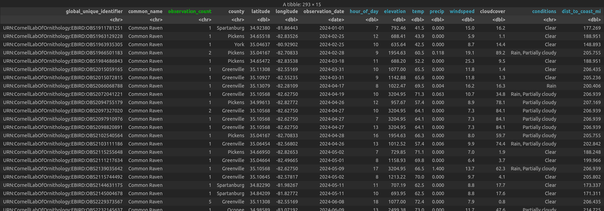

Just for reference:

```r
predictor_cols = c("hour_of_day",
                   "elevation",
                   "dist_to_coast_mi",
                   "temp",
                   "precip",
                   "windspeed",
                   "conditions")
response_col = "observation_count"
```